# Aplicação network analysis - gephi e igraph

### Network Structure

#### Network density

Número de edges dividido pelo número total de edges. Coesão da rede.

```r
#1. Network Density
edge_density(Stucont) # Global density
```

```
## [1] 0.2852097
```

```r
A1<-induced_subgraph(Stucont, V(Stucont)[Class=="1A"], impl=c("auto")) # Subgraphing into each class
edge_density(A1) # Class level density
```

```
## [1] 0.9841897
```

#### Assortativity

Assortativity é a medida que identifica se individuos de um mesmo grupo tendem a se relacionar mais consigo próprios ou com indivíduos de outros grupos (1 e -1 respectivamente)

```r
#2. Assortativity
values <- as.numeric(factor(V(Stucont)$Class)) #values aqui.
assortativity_nominal(Stucont, types=values)
```

```
## [1] 0.2337739
```

O valor de assortativity observado precisa ser comparado com o de um grafo criado aleatoriamente.

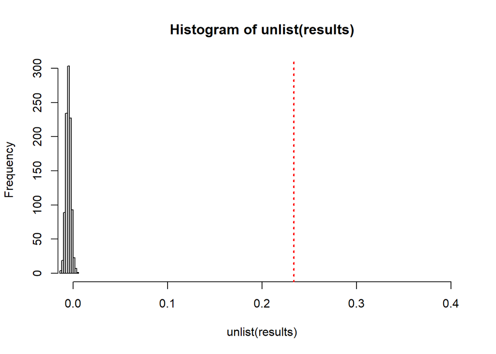

```r
observed.assortativity <- assortativity_nominal(Stucont, types=values)
results <- vector('list', 1000)

for(i in 1:1000){results[[i]] <- assortativity_nominal(Stucont, sample(values))}

#2.2.  Plot the distribution of assortativity values and add a red vertical line at the original observed value
hist(unlist(results), xlim = c(0,0.4))
abline(v = observed.assortativity,col = "red", lty = 3, lwd=2)
```

Uma vez que a linha de assortativity observada é .23 e a amostra de números aleatóriamente gerados está em torno de 0, pode-se inferir que são significativamente diferentes (precisa de algum teste de hipótese ainda, provavelmente um teste T?)

#### Network with Degree Centrality

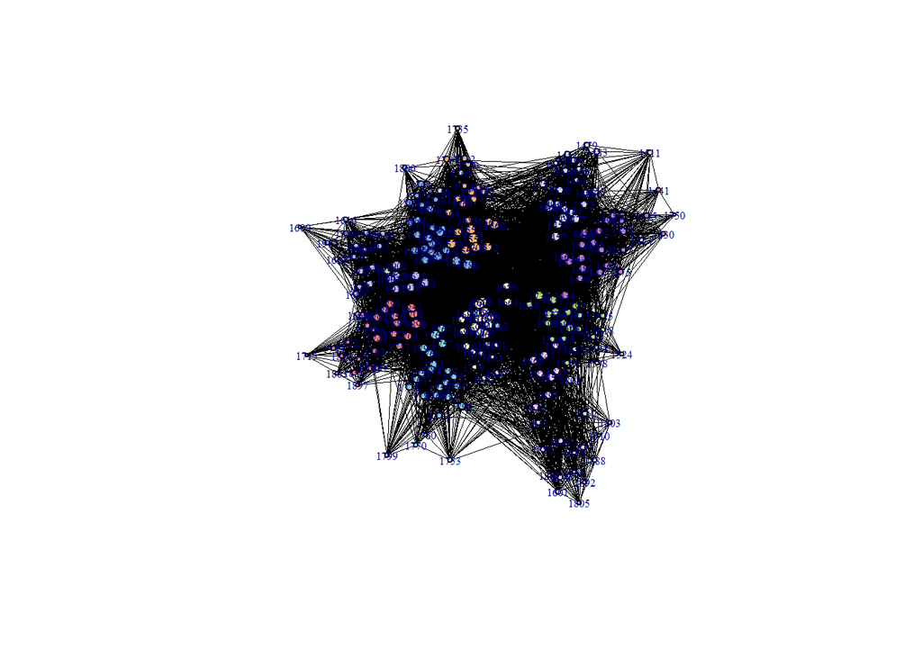

```r
set.seed(1001)

pal<-brewer.pal(length(unique(V(Stucont)$Class)), "Set3") # Vertex color assigned per each class number


plot(Stucont,
     edge.color = 'black',
     vertex.label.cex = 0.5,
     vertex.color = pal[as.numeric(as.factor(vertex_attr(Stucont,
                                                         "Class")))],
     vertex.size = sqrt(Stucont_deg)/2,
     edge.width= sqrt(E(Stucont)$weight/500),
     layout = layout.fruchterman.reingold)
```

#### Visualização Eigenvector centrality

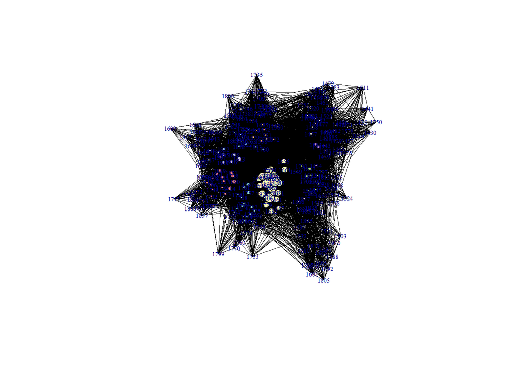

```r
set.seed(1001)
plot(Stucont,
     edge.color = 'black',
     vertex.label.cex = 0.5,
     vertex.color=pal[as.numeric(as.factor(vertex_attr(Stucont, "Class")))],
     vertex.size = sqrt(Stucont_eig)*10, edge.width=sqrt(E(Stucont)$weight/800),
     layout = layout.fruchterman.reingold)
```

#### Visualização betweenness centrality

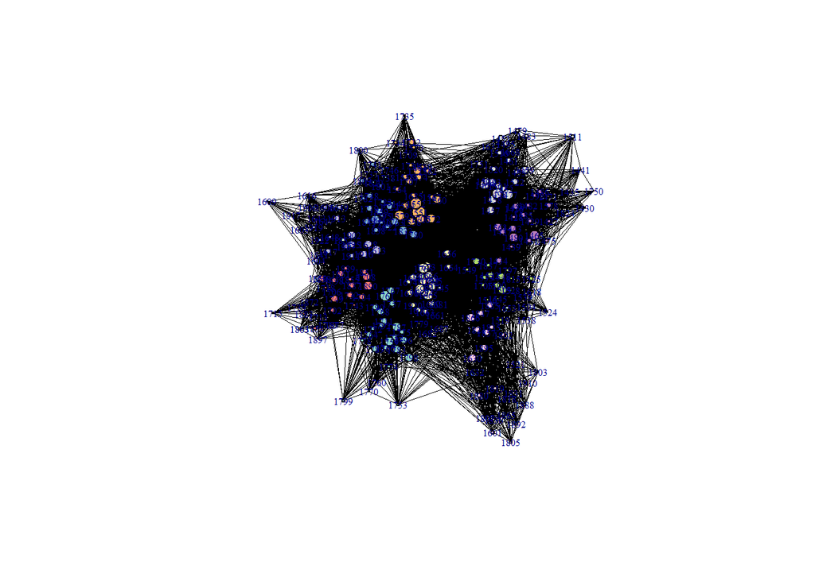

```r
set.seed(1001)
plot(Stucont,edge.color = 'black',vertex.label.cex =0.5,
     vertex.color=pal[as.numeric(as.factor(vertex_attr(Stucont, "Class")))],
     vertex.size = sqrt(Stucont_bw)/3, edge.width=sqrt(E(Stucont)$weight/800),
     layout = layout_with_fr)
```

### Correlações entre indicadores

#### Degree e betweeness

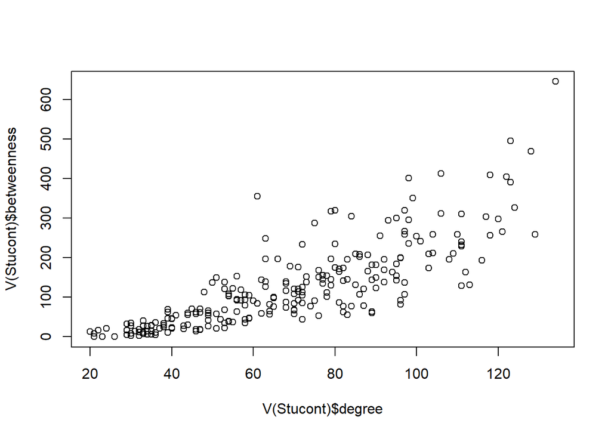

```r
plot(V(Stucont)$degree, V(Stucont)$betweenness)
```

#### Degree e Eigenvector centrality

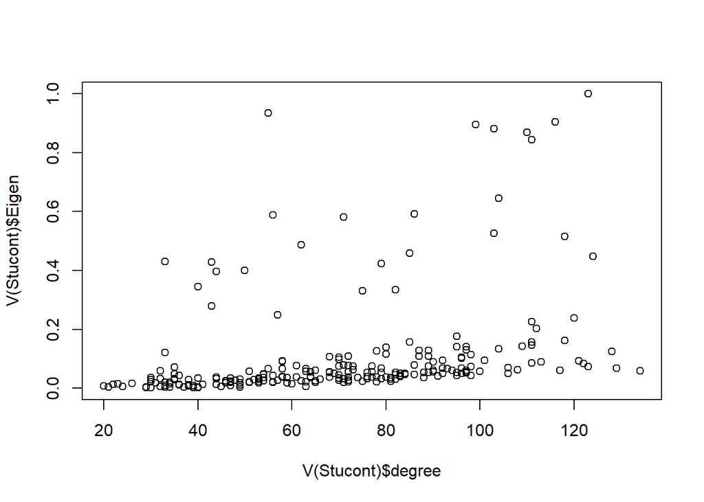

```r
plot(V(Stucont)$degree, V(Stucont)$Eigen)
```

### Community detection - igraph

```r
#1. Louvain clustering
lc <- cluster_louvain(Stucont) # Create a cluster based on the Louvain method
communities(lc) # You can check which vertices belongs to which clusters.
```

```
## $`1`
##  [1] "1426" "1427" "1428" "1429" "1430" "1431" "1434" "1435" "1437" "1439"
## [11] "1441" "1443" "1451" "1452" "1453" "1457" "1458" "1459" "1461" "1465"
## [21] "1468" "1471" "1475" "1477" "1479" "1480" "1482" "1483" "1486" "1489"
## [31] "1493" "1495" "1498" "1501" "1502" "1511" "1516" "1520" "1522" "1563"
## [41] "1578" "1585" "1592" "1637" "1668" "1750" "1751" "1824" "1885"
##
## $`2`
##  [1] "1656" "1661" "1663" "1664" "1665" "1666" "1670" "1673" "1674" "1675"
## [11] "1680" "1681" "1682" "1684" "1687" "1688" "1695" "1696" "1697" "1698"
## [21] "1745" "1765" "1779" "1908" "1912" "1920"
##
## $`3`
##  [1] "1711" "1752" "1753" "1757" "1759" "1760" "1761" "1764" "1766" "1767"
## [11] "1768" "1770" "1772" "1774" "1775" "1778" "1783" "1787" "1789" "1790"
```

[output cut: 23 more lines]

#### Plotagem

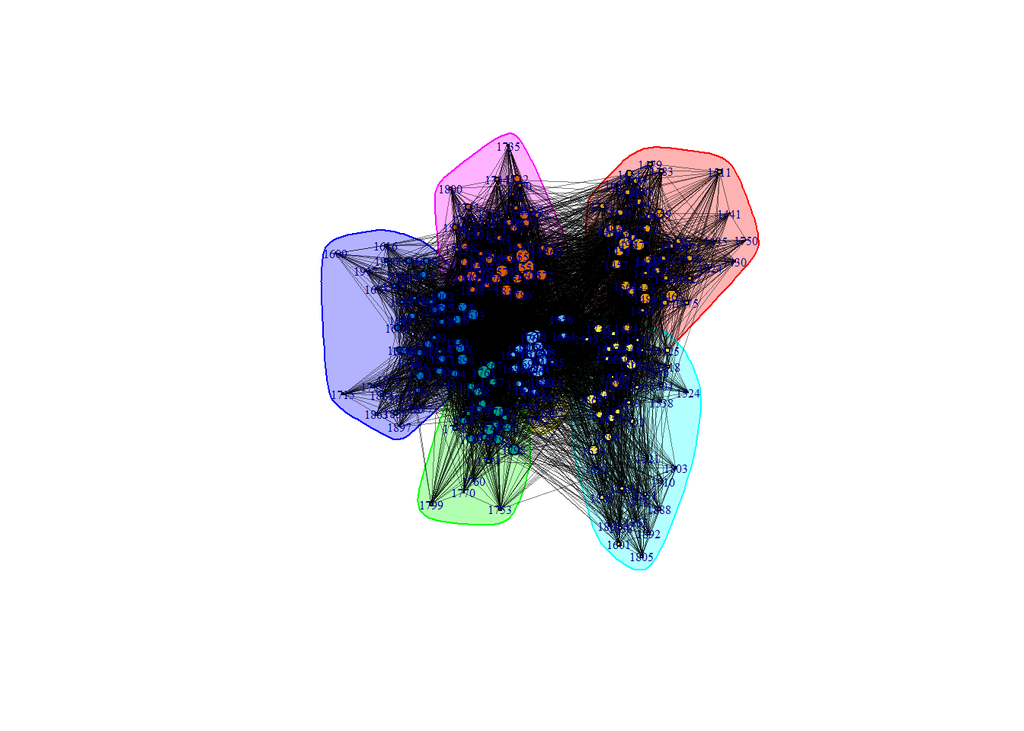

```r
set.seed(1001) # To duplicate the computer process and create exactly the same network repetitively you should set the seed.
plot(lc, Stucont, edge.color = adjustcolor('black', alpha.f = 0.5), vertex.label.cex =0.5,
     vertex.color=pal[as.numeric(as.factor(vertex_attr(Stucont, "Class")))],
     vertex.size = sqrt(Stucont_bw)/3, edge.width=sqrt(E(Stucont)$weight/800),
     layout = layout.fruchterman.reingold)
```

## Abordagem com o ggnet2

ggnet2 e GGally são os pacotes que vão permitir trabalhar com networks num ambiente tidyverse.

**Duas fontes fantásticas:**

https://kateto.net/network-visualization (Aprofundamento no igraph)

https://briatte.github.io/ggnet/ (daqui pra frente)

```r
#install.packages(c('network', 'sna', 'intergraph'))

library(intergraph)
library(GGally)
library(network)
library(sna)
library(ggplot2)
```

### Grafo aleatório

```r
# random bernoulli graph
net = rgraph(10, mode = "graph", tprob = 0.5)
net = network(net, directed = FALSE)

# vertex names
network.vertex.names(net) = letters[1:10]
```

### Visualização do grafo com o ggnet2

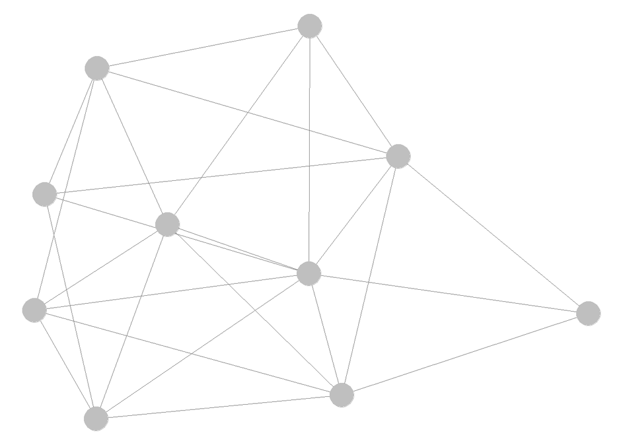

```r
ggnet2(net)
```

O único argumento requerido pelo ggnet2 é um grafo em formato network (transformado pelo pacote)

#### Modificação das cores e do tamanho dos nodos (e grafo da atividade anterior)

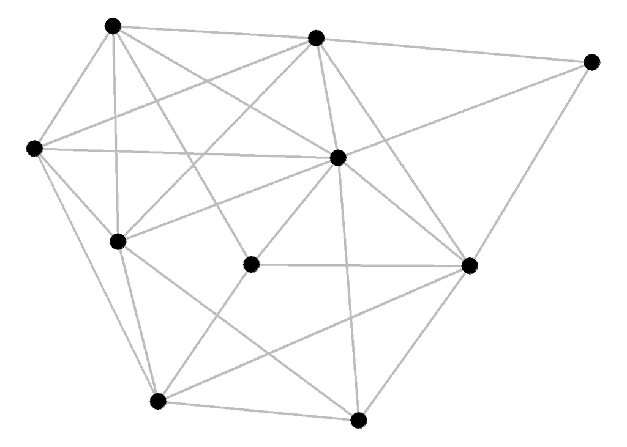

```r
# Argumentos básicos do grafo
ggnet2(net, node.size = 6,
       node.color = "black",
       edge.size = 1,
       edge.color = "grey")
```

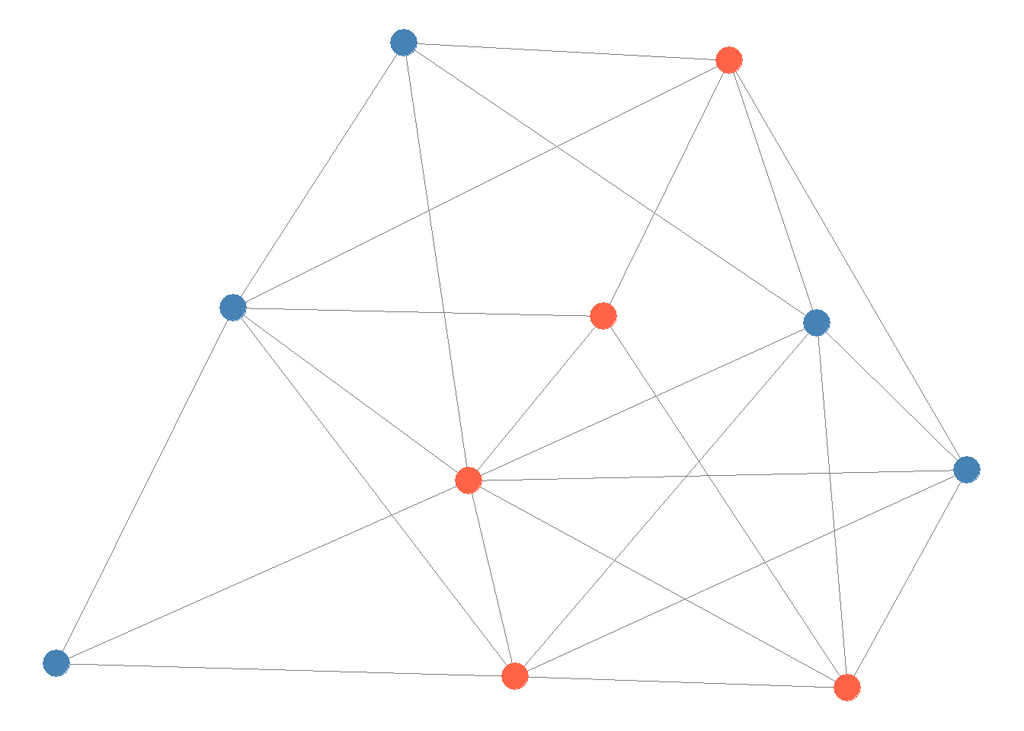

```r
# Definição de cor
ggnet2(net,
       size = 6,
       color = rep(c("tomato", "steelblue"), 5)) #Não parece muito prático
```

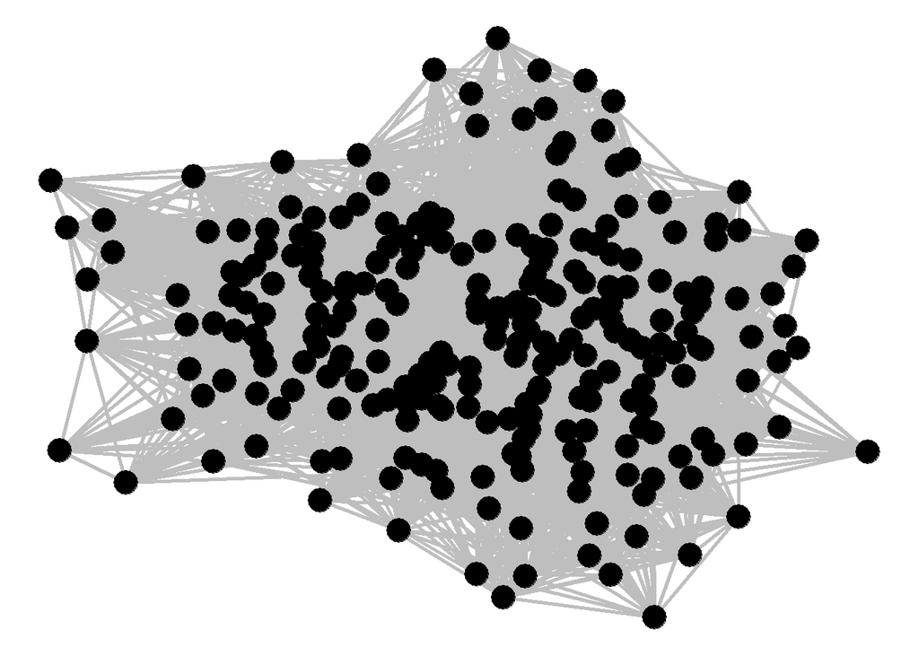

```r
# Tentando com a rede da atividade anterior
ggnet2(Stucont,
       node.size = 6,
       node.color = "black",
       edge.size = 1,
       edge.color = "grey")
```

### Node placement

Default: [Fruchterman-Reingold force-directed algorithm](http://www.rdocumentation.org/packages/sna/functions/gplot.layout)

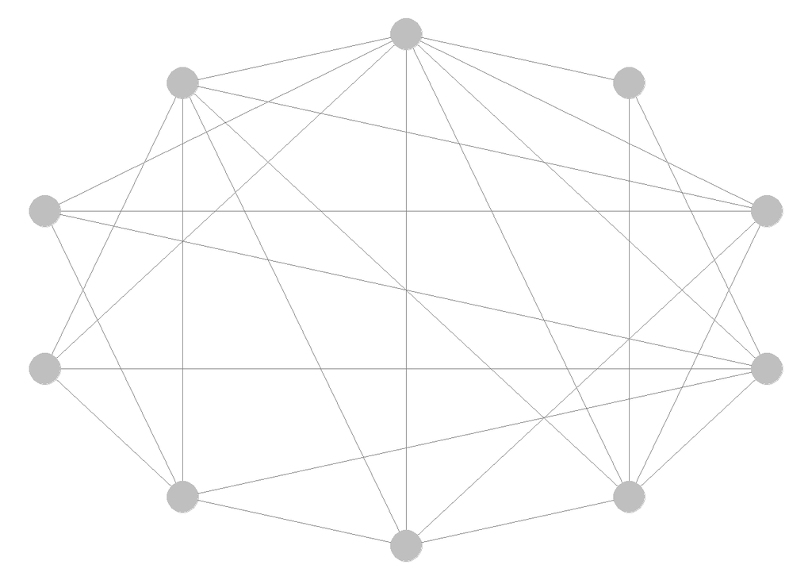

```r
#Outras possibilidades

ggnet2(net, mode = "circle")
```

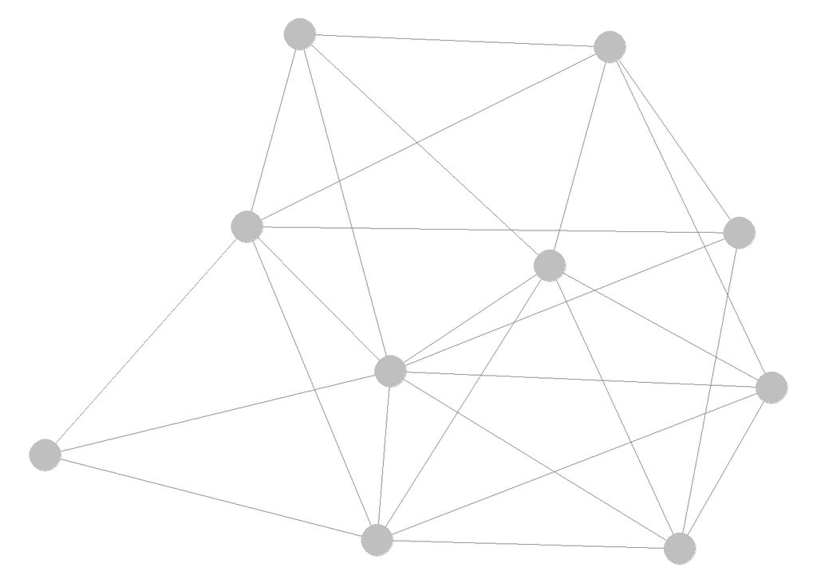

```r
ggnet2(net, mode = "kamadakawai")
```

### Node colors

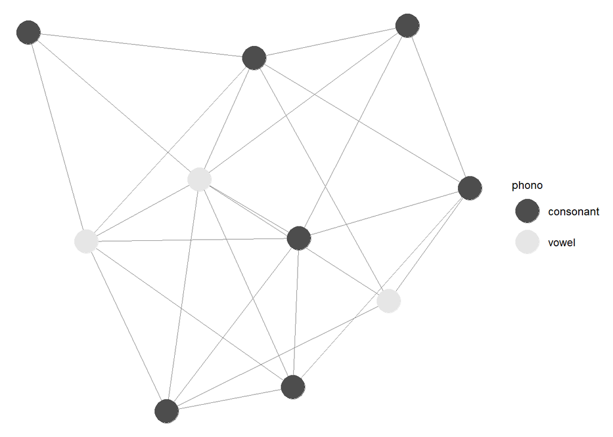

```r
net %v% "phono" = ifelse(letters[1:10] %in% c("a", "e", "i"), "vowel", "consonant")

ggnet2(net, color = "phono")
```

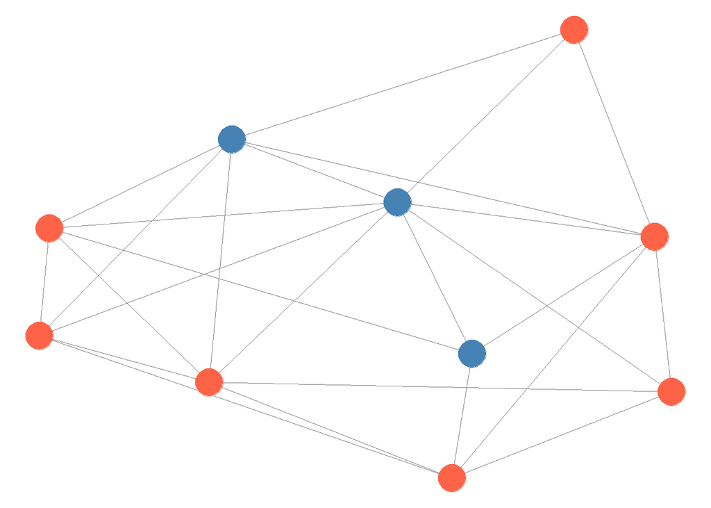

```r
net %v% "color" = ifelse(net %v% "phono" == "vowel", "steelblue", "tomato")
ggnet2(net, color = "color")
```

#### Outras opções de customização de cores

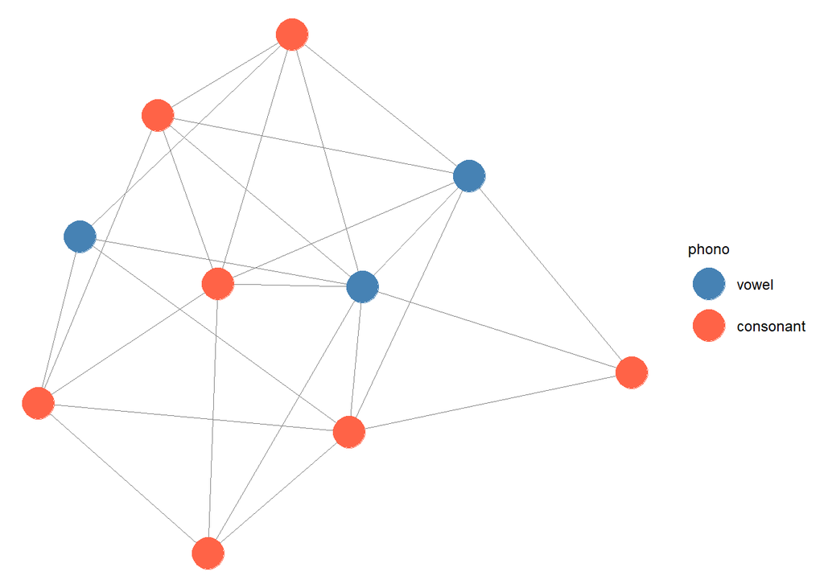

```r
ggnet2(net, color = "phono",
       palette = c("vowel" = "steelblue", "consonant" = "tomato"))
```

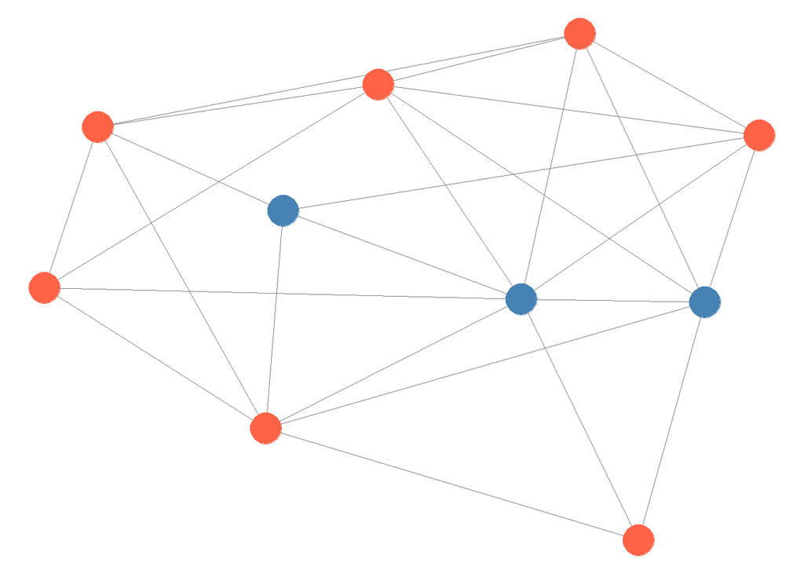

```r
ggnet2(net, color = ifelse(net %v% "phono" == "vowel", "steelblue", "tomato"))
```

#### Paletas pré-definidas

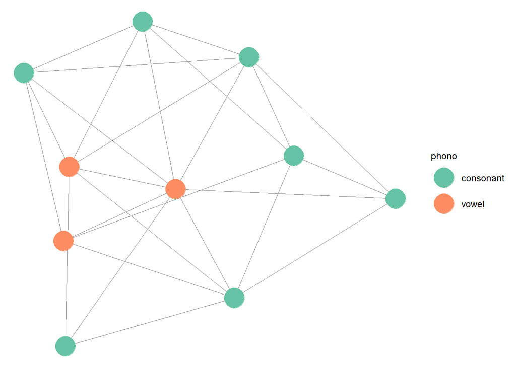

```r
ggnet2(net, color = "phono", palette = "Set2")
```

#### Node sizes

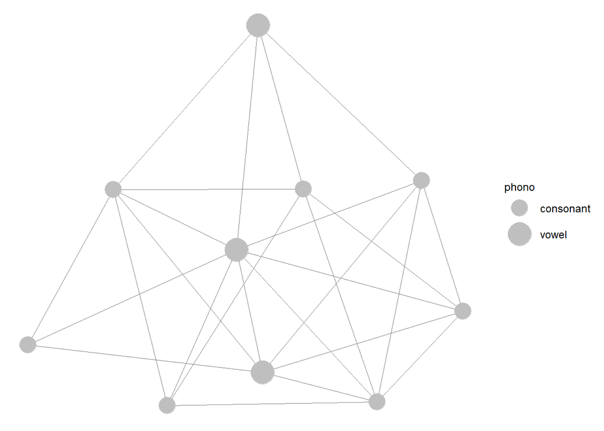

```r
ggnet2(net, size = "phono") #size.palette
```

#### Measure centrality

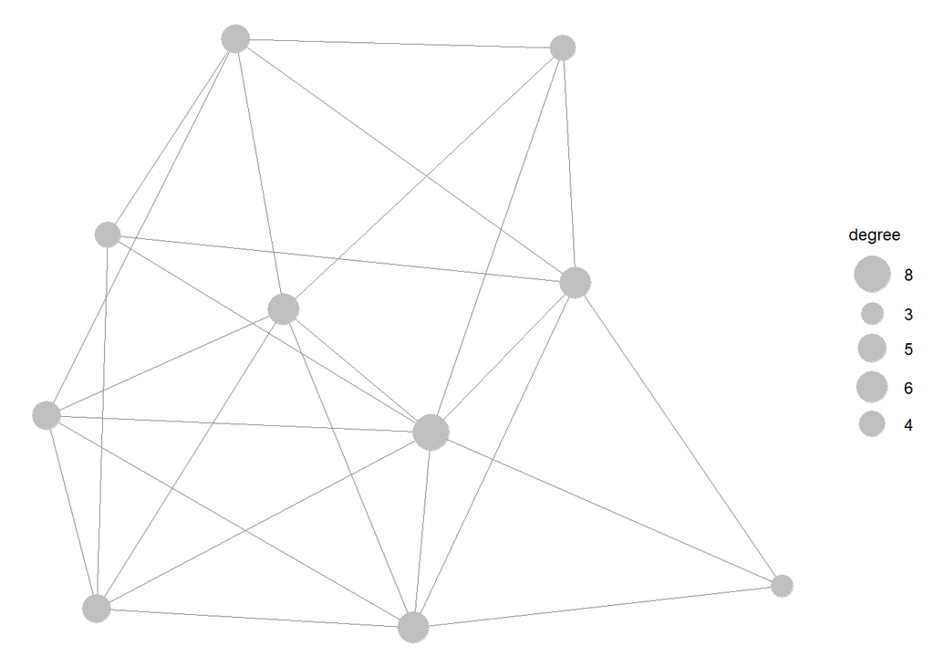

```r
ggnet2(net, size = "degree")
```